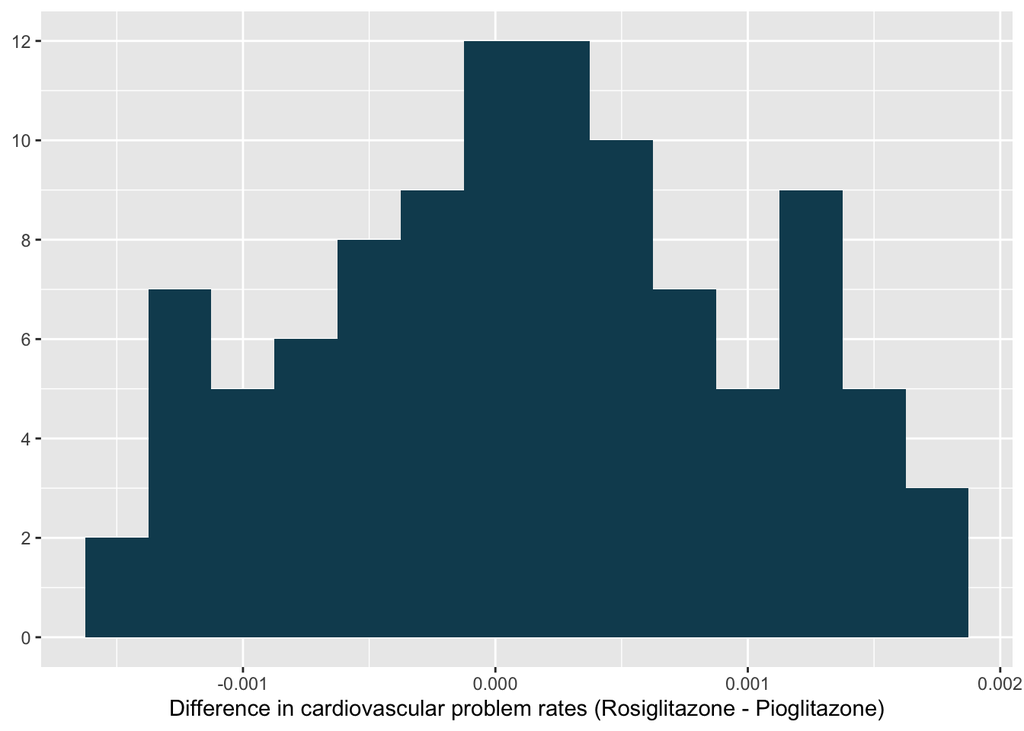

   ```r
   library(infer)
   set.seed(25)
   avandia %>%
     specify(response = cardiovascular_problems, explanatory = treatment, success = "yes") %>%
     hypothesize(null = "independence") %>%
     generate(reps = 100, type = "permute") %>%
     calculate(stat = "diff in props", order = c("Rosiglitazone", "Pioglitazone")) %>%
     ggplot(aes(x = stat)) +
     geom_histogram(binwidth = 0.001/4,  fill = IMSCOL["green", "full"]) +
     labs(y = NULL, x = "Difference in cardiovascular problem rates (Rosiglitazone - Pioglitazone)") +
     scale_y_continuous(breaks = seq(0, 16, 2))
   ```

8. **Heart transplants.** The Stanford University Heart Transplant Study was conducted to determine whether an experimental heart transplant program increased lifespan. Each patient entering the program was designated an official heart transplant candidate, meaning that they were gravely ill and would most likely benefit from a new heart. Some patients got a transplant and some did not. The variable `transplant` indicates which group the patients were in; patients in the treatment group got a transplant and those in the control group did not. Of the 34 patients in the control group, 30 died. Of the 69 people in the treatment group, 45 died. Another variable called `survived` was used to indicate whether or not the patient was alive at the end of the study.[^2] [@Turnbull+Brown+Hu:1974]

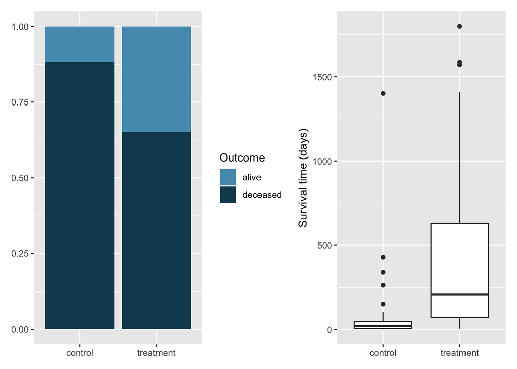

   ```r
   library(tidyverse)
   library(openintro)
   library(patchwork)

   heart_transplant <- heart_transplant %>%
     mutate(survived_better_wording = if_else(survived == "dead", "deceased", as.character(survived)))

   p_bar <- ggplot(heart_transplant, aes(x = transplant, fill = survived_better_wording)) +
     geom_bar(position = "fill") +
     scale_fill_openintro("two") +
     labs(x = NULL, y = NULL, fill = "Outcome")

   p_box <- ggplot(heart_transplant, aes(x = transplant, y = survtime)) +
     geom_boxplot() +
     labs(x = NULL, y = "Survival time (days)")

   p_bar + p_box
   ```

   1. Does the stacked bar plot indicate that survival is independent of whether or not the patient got a transplant? Explain your reasoning.
   2. What do the box plots above suggest about the efficacy (effectiveness) of the heart transplant treatment.
   3. What proportion of patients in the treatment group and what proportion of patients in the control group died?
   4. One approach for investigating whether or not the treatment is effective is to use a randomization technique.
      1. What are the claims being tested?
      2. The paragraph below describes the set up for such approach, if we were to do it without using statistical software. Fill in the blanks with a number or phrase, whichever is appropriate.

      > We write *alive* on $\rule{2cm}{0.5pt}$ cards representing patients who were alive at the end of the study, and *deceased* on $\rule{2cm}{0.5pt}$ cards representing patients who were not. Then, we shuffle these cards and split them into two groups: one group of size $\rule{2cm}{0.5pt}$ representing treatment, and another group of size $\rule{2cm}{0.5pt}$ representing control. We calculate the difference between the proportion of cards in the treatment and control groups (treatment - control) and record this value. We repeat this 100 times to build a distribution centered at $\rule{2cm}{0.5pt}$. Lastly, we calculate the fraction of simulations where the simulated differences in proportions are $\rule{2cm}{0.5pt}$. If this fraction is low, we conclude that it is unlikely to have observed such an outcome by chance and that the null hypothesis should be rejected in favor of the alternative.
      3. What do the simulation results shown below suggest about the effectiveness of the transplant program?

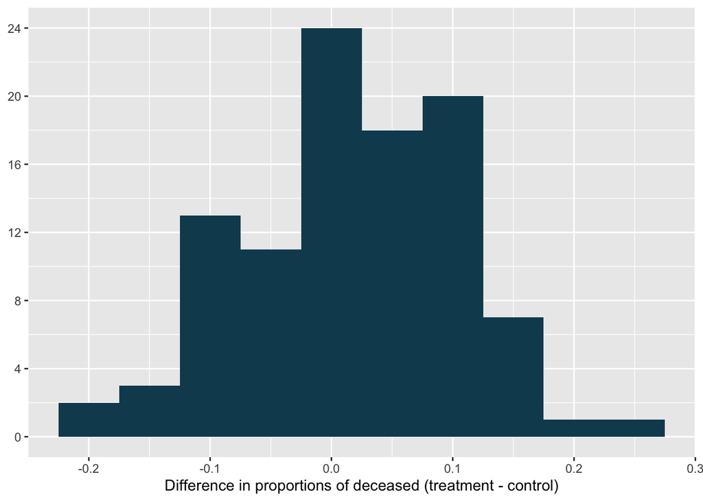

   ```r
   library(infer)
   set.seed(40)
   heart_transplant %>%
     specify(response = survived_better_wording, explanatory = transplant, success = "deceased") %>%
     hypothesize(null = "independence") %>%
     generate(reps = 100, type = "permute") %>%
     calculate(stat = "diff in props", order = c("treatment", "control")) %>%
     ggplot(aes(x = stat)) +
     geom_histogram(binwidth = 0.05, fill = IMSCOL["green", "full"]) +
     labs(y = NULL, x = "Difference in proportions of deceased (treatment - control)") +
     scale_y_continuous(breaks = seq(0, 24, 4), minor_breaks = seq(0, 24, 2))
   ```

[^1]: The [`avandia`](http://openintrostat.github.io/openintro/reference/avandia.html) data used in this exercise can be found in the **openintro** R package.
[^2]: The [`heart_transplant`](http://openintrostat.github.io/openintro/reference/heart_transplant.html) data used in this exercise can be found in the **openintro** R package.